# Simulation Study

In this part we design and perform a simulation study in order to demonstrate functionality of the implemented boosting algorithm. For this, we first employ small models with two location and scale parameters each, and ensure basic functionality. Second, validity of the variable selection features is demonstrated. Lastly, we compare our algorithm with the one implemented in the gamboostLSS package.

In order ensure legibility we employ some helper functions for model initialization, plotting, etc. These and the packages are loaded in the following chunk.

```r
# setting the stage
rm(list=ls())
options(scipen=999)
source("helper_plot_model.R")
source("helper_init_model.R")
source("helper_calc_mse.R")
source("helper_init_large_model.R")
library(asp20boost)
library(gamboostLSS)
library(microbenchmark)
set.seed(1337)
```

## ToDo

- add labels to beta gamma output
- befor every subchapter "Evaluation Config.*", put a formula with the current parameter configuration that is being evaluated.
- add substantial effect in large model to make clear how effect is visible
- try different stepsizes and mstops for other algorithm
- MSE erklären

In case of higher dimensional parameter vectors or idiosyncratic regressors for scale, a look at the distribution of the linear location predictor , as well as the exponentiated scale predictor is of help.

```r
# check model via linear predictors ---------------------------------------------------------
# eta_mu_2 <- init$fitted_loc
# eta_sigma_2 <- init$fitted_scale
#
# hist(eta_mu_2, breaks = 25)
# hist(exp(eta_sigma_2), breaks = 25)
```

## Small Model - Two-dimnesional Case

```r
# config 1 ----------------------
beta_1 <- c(0,1)
gamma_1 <- c(-3,2)

# config 2 ----------------------
beta_2 <- c(2,2)
gamma_2 <- c(2,2)

# config 3 ----------------------
beta_3 <- c(0,1)
gamma_3 <- c(-1,-0.3)

# config 4 ----------------------
beta_4 <- c(0,15)
gamma_4 <- c(1,-1)

# config 7 ----------------------
# beta_7 <- c(0,1)
# gamma_7 <- c(3,-3)
```

```r
mod_1 <- init_model(beta_1, gamma_1, 1000)$model
gradient_boost(mod_1)
mod_2 <- init_model(beta_2, gamma_2, 1000)$model
gradient_boost(mod_2)
mod_3 <- init_model(beta_3, gamma_3, 1000)$model
gradient_boost(mod_3)
mod_4 <- init_model(beta_4, gamma_4, 1000)$model
gradient_boost(mod_4)
```

```r
par(mfrow = c(2,2))
plot_model(beta_1, gamma_1, 1000, "Config 1")
plot_model(beta_2, gamma_2, 1000, "Config 2")
```

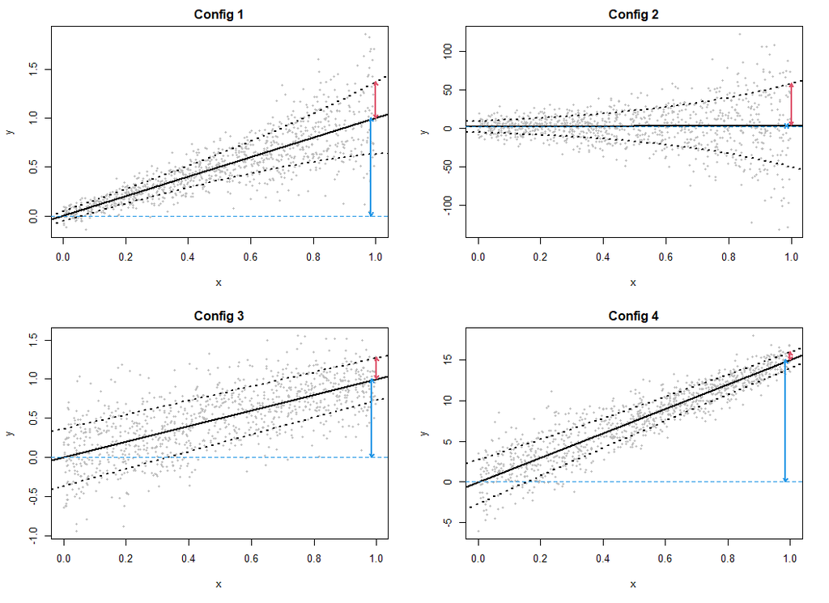

```r
plot_model(beta_3, gamma_3, 1000, "Config 3")
plot_model(beta_4, gamma_4, 1000, "Config 4")
```

```r
result_df <- data.frame("Config" = c(1,1,2,2,3,3,4,4),
                        "beta_true" = c(beta_1, beta_2, beta_3, beta_4),
                        "beta est." = c(round(mod_1$beta, 3), round(mod_2$beta, 3), round(mod_3$beta, 3), round(mod_4$beta, 3)),
                        "gamma_true" = c(gamma_1, gamma_2, gamma_3, gamma_4),
                        "gamma est." = c(round(mod_1$gamma, 3), round(mod_2$gamma, 3), round(mod_3$gamma, 3), round(mod_4$gamma, 3))
                        )
result_df
```

| Config | beta_true | beta.est. | gamma_true | gamma.est. |
| --- | --- | --- | --- | --- |
| 1 | 0 | -0.006 | -3.0 | -2.951 |
| 1 | 1 | 1.019 | 2.0 | 1.944 |
| 2 | 2 | NaN | 2.0 | NaN |
| 2 | 2 | NaN | 2.0 | NaN |
| 3 | 0 | -0.020 | -1.0 | -0.947 |
| 3 | 1 | 1.037 | -0.3 | -0.475 |
| 4 | 0 | 1.270 | 1.0 | 0.838 |
| 4 | 15 | -0.245 | -1.0 | 1.944 |

### Evaluation Configuration 1

#### Evaluation Configuration 2

Configuration 2 is a somewhat naive parameter configuration, where all parameters are set to value 2. Estimating this model does not yield valid results. The gradient_boost() function runs into numerical problems. To understand why this happens we need to understand the model characteristics resulting from parameter configuration 2-2-2-2. Here, the red arrow is of large size, while the blue arrow is hardly visible. This is due to the presence of huge standard deviations in response *y*, concealing changes in expectation of *y.* In fact, the standard deviation at x = 1 is:

```r
exp(gamma_2[1] + gamma_2[2] * 1)
```

```
[1] 54.59815
```

#### Evaluation Configuration 3

Configuration 3, in turn, yields reasonable estimates. It contains a negative gamma slope, leading to decreasing response standard deviations. This can be observed by the funnel shape pointing in the opposite direction as before.

It may be of interest to check if estimates are fit better (if they lie closer to the true parameters) than e.g. in configuration 1. To do this we measure the gap between true values and estimates by the mean squared error. This enables comparison of configurations 1 and 3.

```r
mse_1 <- calc_MSE(beta_1, gamma_1, mod_1$beta, mod_1$gamma)
mse_3 <- calc_MSE(beta_3, gamma_3, mod_3$beta, mod_3$gamma)
cbind("config 1" = mse_1,
      "config_3" = mse_3)
```

```
      config 1     config_3
beta  0.0003999613 0.001758186
gamma 0.005490317  0.03329887
total 0.005890278  0.03505706
```

#### Evaluation Configuration 4

In configuration 4, we again included a negative gamma slope, as well as a very high beta slope. The idea is to ensure a very good signal noise ratio, in order to ensure good model fit, indicated by low MSE. Contrary to our expectations, the algorithm performs poorly for this parameter configuration.

```r
mse_4 <- calc_MSE(beta_4, gamma_4, mod_4$beta, mod_4$gamma)
cbind("config 1" = mse_1,
      "config_3" = mse_3,
      "config 4" = mse_4)
```

```
      config 1     config_3    config 4
beta  0.0003999613 0.001758186 234.0104
gamma 0.005490317  0.03329887  8.694547
total 0.005890278  0.03505706  242.7049
```

The bad model fit is due to the fact, that the location slope is exceptionally underestimated.

### Conclusions

The observed two-dimensional cases let us conclude that not every arbitrary parameter configuration is estimable by the implemented gradient_boost() algorithm. A first insight is that signal-noise ratio needs to be sufficiently high in order to prevent that location effect gets concealed by inflated standard deviations.

## Large Model - Variable Selection in the multidimensional case

### ToDo

This may be improved by setting less maxit. However this may lead to move away from the yet quite optimal choice for *beta*. It could also be improved by lowering stepsize for gamma. This results in a pattern where the latter entries of gamma are chosen exactly wrong. We will observe this pattern also in the next examples and have no explanation.

### Setup 1

For models with many regressors componentwise boosting allows to perform variable selection. The helper function *init_large_model* creates sample data. The parameter vectors beta and gamma are of size *dim_param* and contain some zeros. The non-zero elements are assigned random values in the specified ranges.

```r
# initialize model-----------------------------------------------
init_1 <- init_large_model(beta_range = c(5,10),
                           gamma_range = c(0.5,1),
                           dim_param = 5,
                           int_gamma = -0.2,
                           n = 100)
mod_1 <- init_1$model
cbind(beta_true = init_1$beta, gamma_true = init_1$gamma)
```

```
     beta_true gamma_true
[1,]         6       -0.2
[2,]         0        0.0
[3,]         0        0.7
[4,]         9        0.0
[5,]         0        0.6
[6,]         8        0.0
```

In *mod_1* beta and gamma ranges are chosen in order to create a model that is estimable. In the multidimensional it is again important to create data with a balanced signal-noise ratio. If gamma parameters add up to high values, the resulting simulated response has huge standard deviation, which conceals the location effects.

In the twodimensional case we used plots to check this ratio. Now, we have a look at the unit-wise location predictors *eta_mu*, as well as the exponentiated scale predictors *exp(eta_sigma)*, which determine the response sd.

```r
cbind("eta_mu" = rbind(mean = mean(init_1$fitted_response), var = var(init_1$fitted_response)),
      "exp_eta_sigma" = rbind(mean = mean(init_1$fitted_sd), var = var(init_1$fitted_sd)))
```

```
         [,1]      [,2]
mean 14.64092 1.6700566
var  12.87169 0.2003414
```

Plotting the empirical distributions of *eta_mu* and *exp_eta_sigma* as histograms gives a visual and more detailed overview of the location-scale regression model characteristics given the assigned parameters *beta* and *gamma*

[figure not shown]

```r
par(mfrow=c(2,1))
hist(init_1$fitted_response, breaks = 25, main = "eta_mu")
hist(init_1$fitted_sd, breaks = 25, main = "exp_eta_sigma")
```

Performing the boosting alogrithm by calling the gradient_boost() function leads to the follwing results.

```r
gradient_boost(mod_1, stepsize = c(0.1,0.001), maxit = 1000, componentwise = TRUE)

cbind(true = init_1$beta, estimate = round(mod_1$beta,2))
```

```
     true estimate
[1,]    6     8.07
[2,]    0     0.00
[3,]    0     0.00
[4,]    9     6.64
[5,]    0     0.00
[6,]    8     5.64
```

```r
cbind(true = init_1$gamma, estimate = round(mod_1$gamma,2))
```

```
     true estimate
[1,] -0.2     0.22
[2,]  0.0    -0.09
[3,]  0.7     0.01
[4,]  0.0     0.61
[5,]  0.6     0.00
[6,]  0.0     0.52
```

The values estimated differ considerably from the true parameter values. The resulting MSE is higher than in the four parameter case.

```r
calc_MSE(init_1$beta, init_1$gamma, mod_1$beta, mod_1$gamma)
```

```
$beta
[1] 4.271639

$gamma
[1] 0.1823184

$total
[1] 4.453957
```

### Setup 2

We scale dimension of the parameter vectors up to 10.

```r
init_2 <- init_large_model(c(3,6), c(0.2,0.8), 10, -0.2, n = 100)
mod_2 <- init_2$model
cbind(beta_true = init_2$beta, gamma_true = init_2$gamma)
```

```
      beta_true gamma_true
 [1,]         3       -0.2
 [2,]         0        0.0
 [3,]         0        0.7
 [4,]         6        0.0
 [5,]         0        0.6
 [6,]         6        0.0
 [7,]         5        0.4
 [8,]         0        0.0
 [9,]         0        0.7
[10,]         5        0.0
[11,]         0        0.7
```

[figure not shown]

```r
par(mfrow=c(2,1))
hist(init_2$fitted_response, breaks = 25, main = "eta_mu")
hist(init_2$fitted_sd, breaks = 25, main = "exp_eta_sigma")
```

```r
gradient_boost(mod_2, stepsize = c(0.1,0.01), maxit = 1000, componentwise = TRUE)
```

```
NA
```